# UMD Client Analysis

## Introduction

Urban Ministries of Durham is a local, non-profit organization that works with the community to end homelessness and fight poverty by offering food, shelter and other services to those in need.

UMD has generously provided us with some of the data from records they have been keeping on past services provided to their clients. All data for this project come from the datafiles provided to us by UMD.

data source: https://github.com/biodatascience/datasci611/tree/gh-pages/data/project2_2019

## What are some of the demographics of UMD clients?

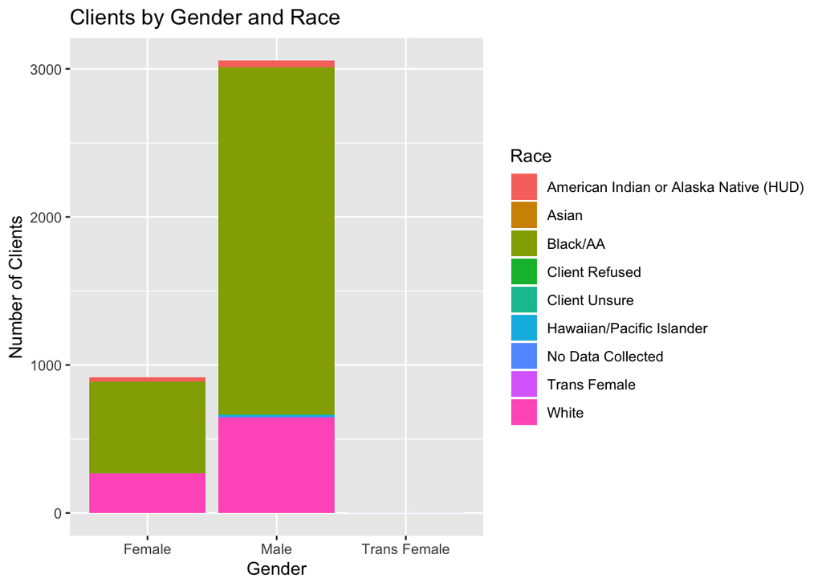

Around 80% of clients are male. The largest racial group is Black/African American, followed next by White.

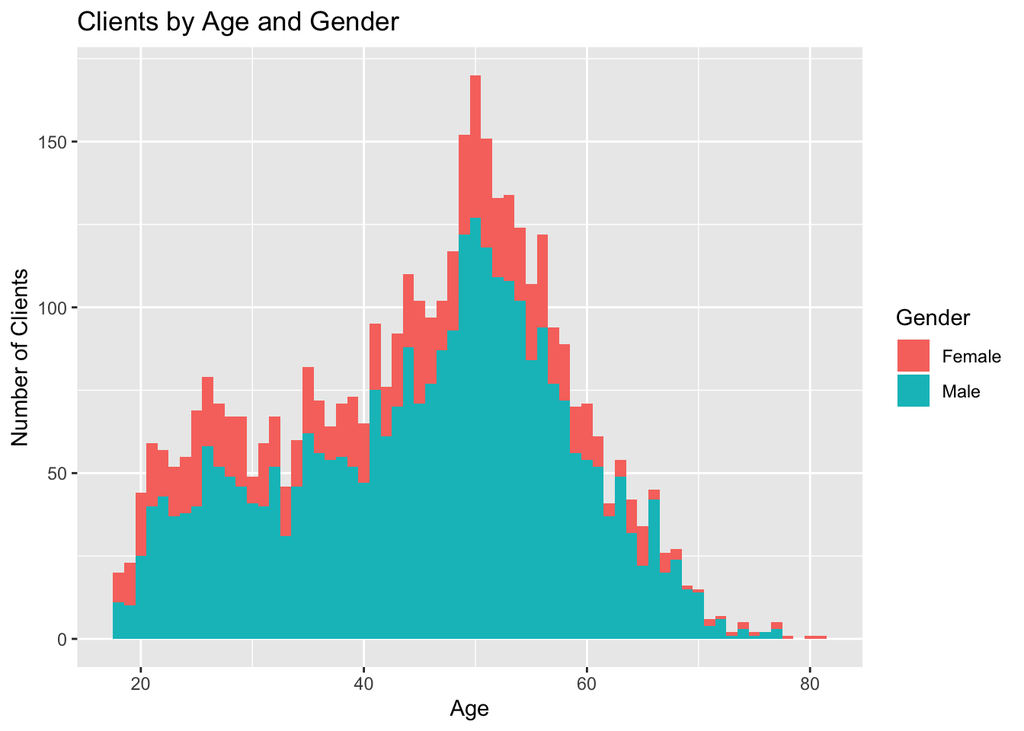

Most clients are between 40-60 years old at entry, with early 50s the highest represented. A significant but smaller number are between the ages of 20-40.

## What do we know about clients’ situational information prior to entry at UMD?

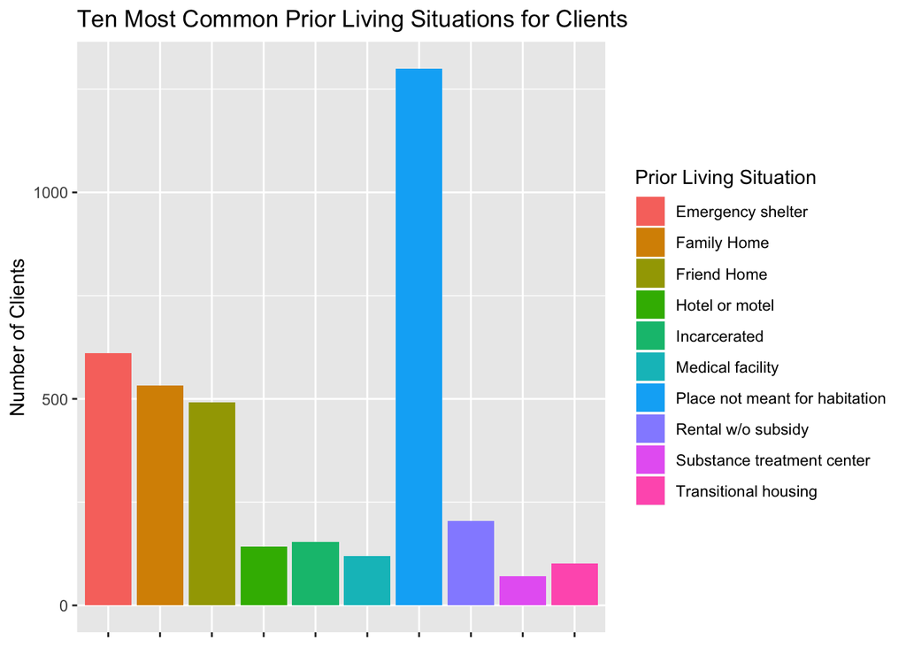

By far the most common previous living situation for clients is ‘Place not meant for habitation,’ followed significantly behind by ‘Emergency shelter,’ ‘Family Home’ and ‘Friend Home.’ One thing that this implies is most people come to UMD after already being homeless for a period of time, so it is not the first place most people turn to after becoming homeless.

Let’s take a closer look at prior living situation for clients by adding in data about how many times these clients have been homeless in the past three years

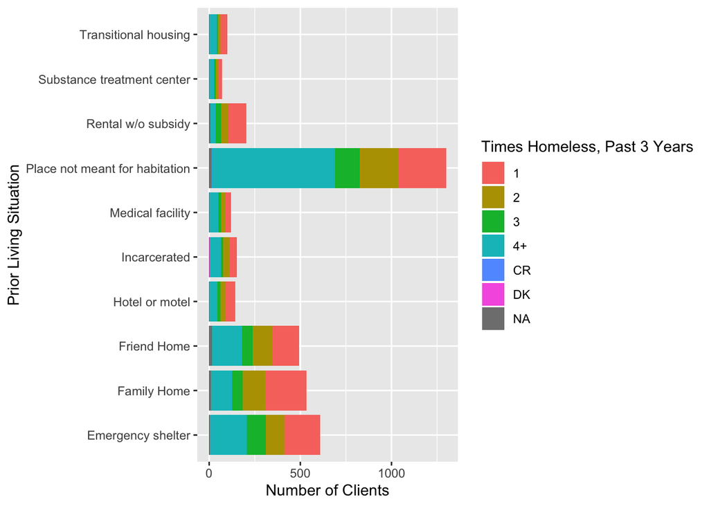

Something interesting we see is that the highest and lowest categories are the two most common; most clients are either homeless for the first time, or they have been homeless at least four times before. Somewhat smaller numbers of clients are in between those two extremes.

# How long were clients living at their previous location?

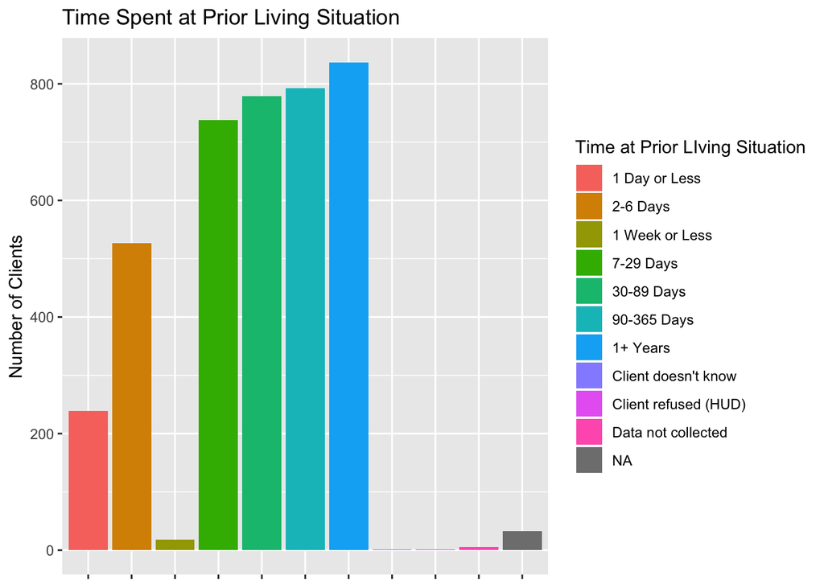

We can again have a closer look by comparing this data with previous living situation for clients.

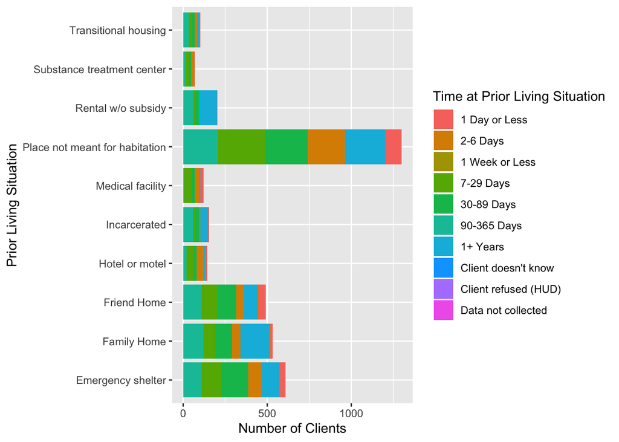

This again shows a mostly mixed situation for clients; there are no immediately obvious patterns about correlation between prior living situation and time spent there.

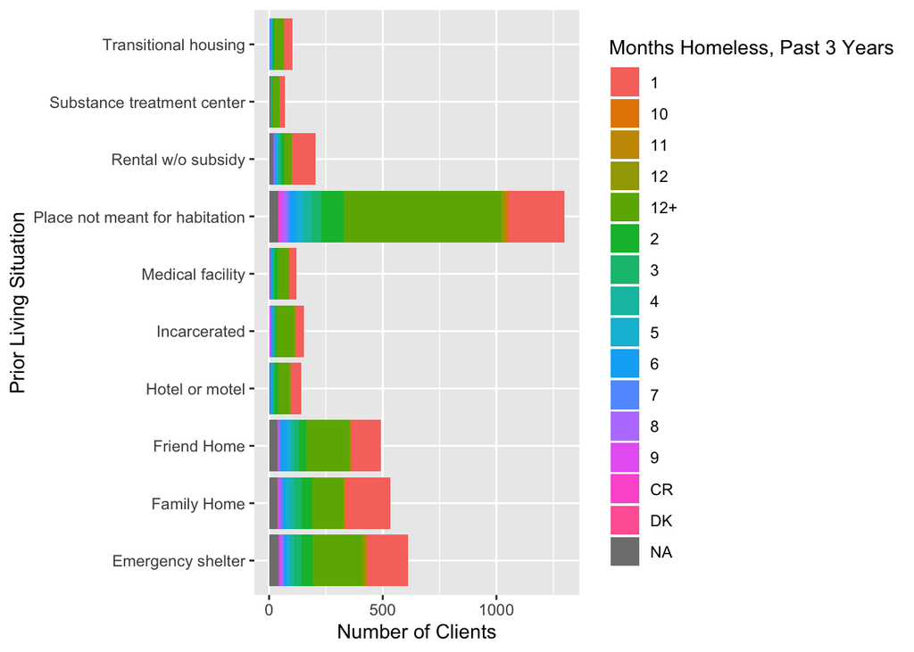

Here we again see a similar pattern to our previous graph comparing number of times clients have been homeless with their previous living situation: The two most common groups are those who have been homeless for less than one month in the past three years, and those who have been homeless for more than twelve months.

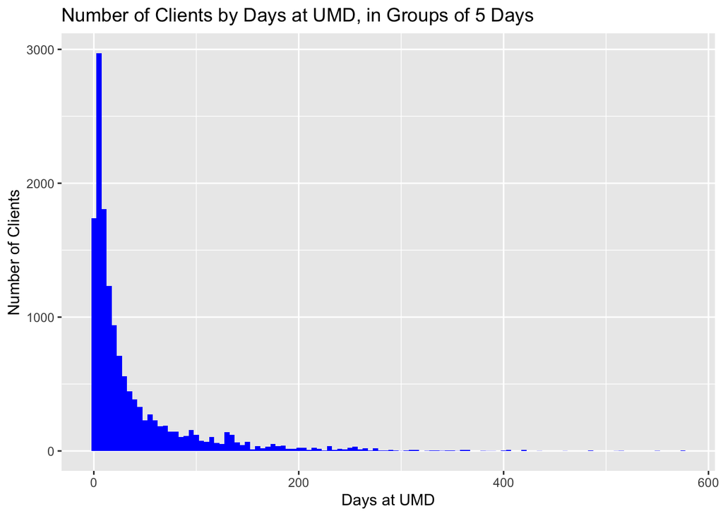

Here, we can see the majority of clients stay between 1 and 15 days, with a very select few staying over one year.

# When are clients entering the system?

Group client entry dates by month and add a trend line to see if there are any noticeable patterns.

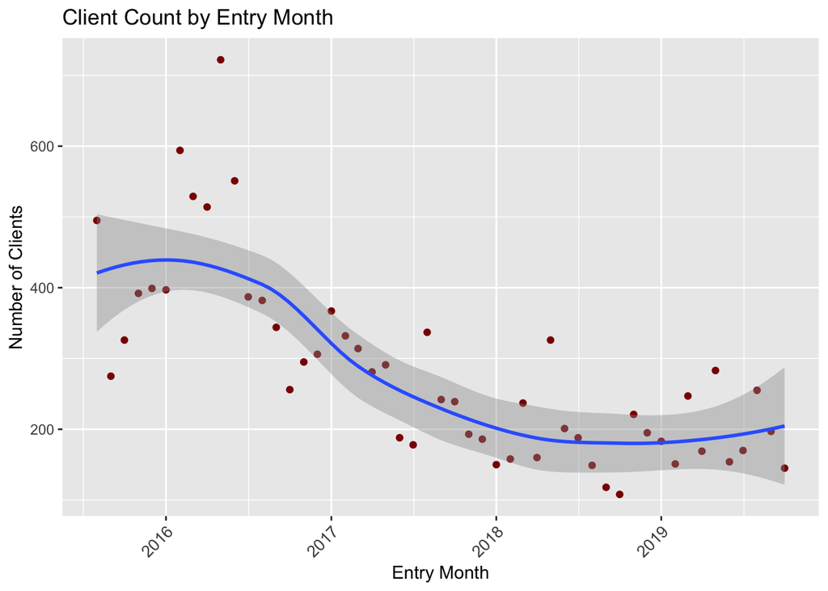

Here we see the number of clients entering the system have declined over time.

Next, combine months from each year to look at seasonal trends.

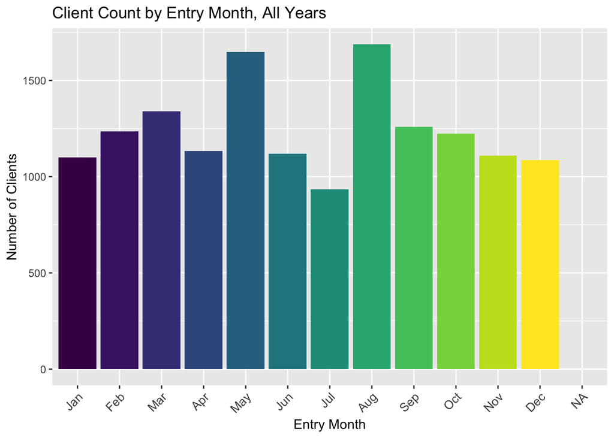

From this graph we see that May and August are the two busiest months for client entry, with lulls in the middle of winter and summer months. There are not many other clear differences between months.

# Why are clients leaving the program?

Compare how many clients leave for which reasons.

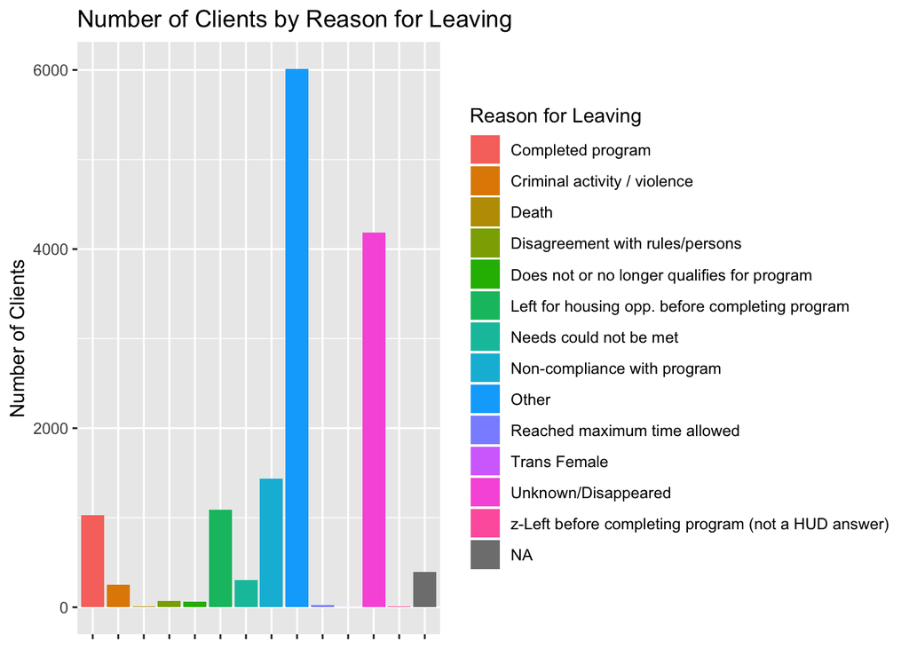

Here we also clearly see that Other and Unknown/Disappeared are the most common reasons. Significantly far behind are Non-compliance with program, Left for housing opp. before completing the program and Completed program.

# Where are clients going after leaving?

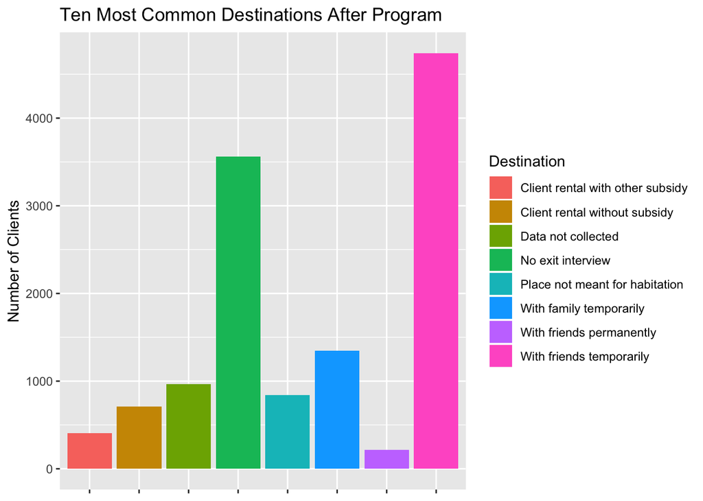

By far the largest number of clients stay with friends temporarily after departure, while nearly as many clients do not give an exit interview. The next most common destination are with family temporarily, although it is significantly behind the first two.

Finally, we look at all client exits to find trends over time in their stay duration and destination.

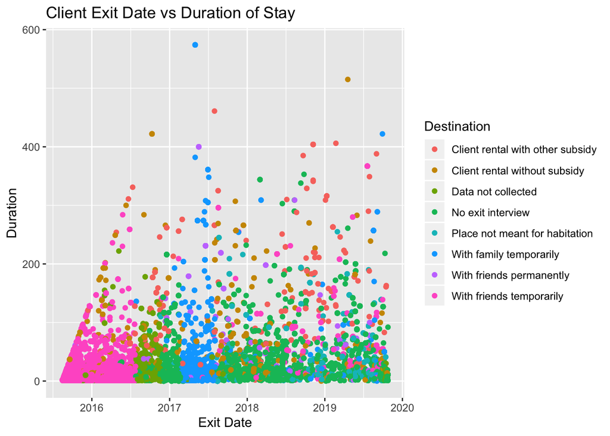

It appears that the large majority of clients who left to stay with friends temporarily did so in the first two years. Between 2017 and 2018, a large number of clients left to stay with family temporarily, and most recently, more clients appear to be leaving without an exit interview. Recently, slightly higher number appear to be leaving for a place not meant for habitation as well.

## Conclusions

After making these intial observations, I would want to sit down with UMD staff to see what areas they may want to investigate further, and to see what new questions they may now have to help us take our next steps.